# R Notebook

```r
#in order to run this code, you will need to install these packages. You can do so by going to the install button, or by going to the console and typing, for example, install.packages("knitr")
suppressPackageStartupMessages(library(knitr)) #makes pdfs
suppressPackageStartupMessages(library(latex2exp))
suppressPackageStartupMessages(library(tidyverse)) #good library for data manipulation, includes dplyr and ggplot
suppressPackageStartupMessages(library(retrosheet))
suppressPackageStartupMessages(library(Lahman))
suppressPackageStartupMessages(library(data.table))

# you can read more about the tidyverse at: https://r4ds.had.co.nz/
knitr::opts_chunk$set(echo = TRUE)
```

Create the Files

```r
# setwd("/Users/rcarino/Desktop/Wii Baseball Project/Rays/")
# files <- list.files(pattern = ".csv")
# temp <- lapply(files, fread, sep=",")
# data <- rbindlist(temp)
# write.csv(data, file="Rays_2015_2023.csv", row.names = FALSE)
```

Read in CSV

```r
retro_sheet_column_names <- c(
  "game_id", "visiting_team_df", "inning", "batting_team_df", "outs", "balls",
  "strikes", "pitch_sequence", "vis_score", "home_score", "batter",
  "batter_hand", "res_batter", "res_batter_hand", "pitcher", "pitcher_hand",
  "res_pitcher", "res_pitcher_hand", "catcher", "first_base", "second_base",
  "third_base", "shortstop", "left_field", "center_field", "right_field",
  "first_runner", "second_runner", "third_runner", "event_text",
  "leadoff_flag", "pinchhit_flag", "defensive_position", "lineup_position",
  "event_type", "batter_event_flag", "ab_flag", "hit_value", "SH_flag",
  "SF_flag", "outs_on_play", "double_play_flag", "triple_play_flag",
  "RBI_on_play", "wild_pitch_flag", "passed_ball_flag", "fielded_by",
  "batted_ball_type", "bunt_flag", "foul_flag", "hit_location", "num_errors",
  "1st_error_player", "1st_error_type", "2nd_error_player", "2nd_error_type",
  "3rd_error_player", "3rd_error_type", "batter_dest",
  "runner_on_1st_dest", "runner_on_2nd_dest", "runner_on_3rd_dest",
  "play_on_batter", "play_on_runner_on_1st", "play_on_runner_on_2nd",
  "play_on_runner_on_3rd", "SB_for_runner_on_1st_flag",
  "SB_for_runner_on_2nd_flag", "SB_for_runner_on_3rd_flag",
  "CS_for_runner_on_1st_flag", "CS_for_runner_on_2nd_flag",
  "CS_for_runner_on_3rd_flag", "PO_for_runner_on_1st_flag",
  "PO_for_runner_on_2nd_flag", "PO_for_runner_on_3rd_flag",
  "Responsible_pitcher_for_runner_on_1st",
  "Responsible_pitcher_for_runner_on_2nd",
  "Responsible_pitcher_for_runner_on_3rd", "New_Game_Flag",
  "End_Game_Flag", "Pinch_runner_on_1st", "Pinch_runner_on_2nd",
  "Pinch_runner_on_3rd", "Runner_removed_for_pinch_runner_on_1st",
  "Runner_removed_for_pinch_runner_on_2nd",
  "Runner_removed_for_pinch_runner_on_3rd",
  "Batter_removed_for_pinch_hitter",
  "Position_of_batter_removed_for_pinch_hitter",
  "Fielder_with_First_Putout", "Fielder_with_Second_Putout",
  "Fielder_with_Third_Putout", "Fielder_with_First_Assist",
  "Fielder_with_Second_Assist", "Fielder_with_Third_Assist",
  "Fielder_with_Fourth_Assist", "Fielder_with_Fifth_Assist", "event_num"
)
```

## Let’s load in the Data

```r
# team_df = read.csv("/Users/rcarino/Desktop/Wii Baseball Project/Mets/Mets_2015_2023.csv", header = FALSE )
# team_df = read.csv("/Users/rcarino/Desktop/Wii Baseball Project/Dodgers/Dodgers_2015_2023.csv", header = FALSE )
# team_df = read.csv("/Users/rcarino/Desktop/Wii Baseball Project/Yankees/Yankees_2015_2023.csv", header = FALSE )
# team_df = read.csv("/Users/rcarino/Desktop/Wii Baseball Project/Giants/Giants_2015_2023.csv", header = FALSE )
# team_df = read.csv("/Users/rcarino/Desktop/Wii Baseball Project/Rays/Rays_2015_2023.csv")
team_df = read.csv("/Users/rcarino/Desktop/Wii Baseball Project/Angels/Angels_2015_2023.csv", header = FALSE )

colnames(team_df) <- retro_sheet_column_names
team_df <- team_df[-1,] #RBIND ADDITION
team_df$outs <- as.integer(team_df$outs)#RBIND ADDITION
team_df$event_type <- as.integer(team_df$event_type)#RBIND ADDITION

total_events = nrow(team_df)
View(team_df)
```

## Let’s Add in Our Assumptions:

```r
# Remove All Double Plays and Triple Plays
team_df = team_df[team_df$outs_on_play < 2,]
# Only Have Walks, Single, Doubles, Triples, and Homeruns, General Outs, Strikeouts
team_df <- subset(team_df, team_df$event_type == 2 | team_df$event_type == 3 | team_df$event_type == 14
                       | team_df$event_type == 20 | team_df$event_type == 21 | team_df$event_type == 22
                       | team_df$event_type == 23)
```

```r
# Calculate The Total Number of Homeruns
total_hrs = 0
for (i in 1:nrow(team_df)) {
  if (team_df$event_type[i] == 23) {
    total_hrs <- total_hrs + 1
  }
}
total_hrs
```

```
[1] 1760
```

## Print Number of Total Events: This is basically going to be the denominator

```r
total_events = nrow(team_df)
total_events
```

```
[1] 48850
```

## Let’s Set Up the Wii Sports Baseball Matrix

```r
# Before
# baseball_matrix<- matrix(0, nrow = 25, ncol = 25)
# After
baseball_matrix<- matrix(0, nrow = 25, ncol = 25)
baseball_matrix
```

[output not shown]

## Helper Functions to Populate Baseball Matrix

This function will return a list that will contain the row and col index values so we can index into the baseball matrix (24 x 24) (with an additional row and column for the absorbing state) when iterating through the dataframe on the next cell. This function will handle all the events where there are no runners on base

```r
no_runners_on <- function(outs, event, outs_on_play) {
  # Event For Homerun
  from_index = 1 + (8 * outs)
  # Event For Single
  if (event == 20 || event == 14) {
    return (c(from_index, from_index + 1))
  }
  # Event For Double
  if (event == 21) {
    return (c(from_index, from_index + 2))
  }
  # Event For Triple
  if (event == 22) {
    return (c(from_index, from_index + 3))
  }
  # Event For Homerun
  if (event == 23) {
    return (c(from_index, from_index))
  }
  # 0 Outs -> 1 Out
  if (event == 2 || event == 3 && outs == 0 && outs_on_play == 1) {
    return(c(from_index, from_index + 8))
  }
  # 1 Out -> 2 Outs
  if (event == 2 || event == 3 && outs == 1 && outs_on_play == 1) {
    return(c(from_index, from_index + 8))
  }
    # Will Handle 2 Outs -> 3 Outs Later  {WOULD  RECCOMEND PUTTING THE 2 OUTS -> 3 OUTS STATEMENT ABOVE}
  # 2 Outs -> 3 Outs
  if ((event == 2 || event == 3) && outs == 2 && outs_on_play == 1) {
    return(c(17, 25))
  }

  #Edge Case -> There are Outs_on_Play = 0 Just Return [0, 0]
  return(c(0, 0))
}
```

This function will return a list that will contain the row and col index values so we can index into the baseball matrix (24 x 24) when iterating through the dataframe on the next cell. This function will handle all the events where there are runners on first base

```r
runner_on_first <- function(outs, event, outs_on_play) {
  # Event For Homerun
  from_index = 2 + (8 * outs)
  # Event For Single
  if (event == 20 || event == 14) {
    return (c(from_index, from_index + 3))
  }
  # Event For Double
  if (event == 21) {
    return (c(from_index, from_index + 5))
  }
  # Event For Triple
  if (event == 22) {
    return (c(from_index, from_index + 2))
  }
  # Event For Homerun
  if (event == 23) {
    return (c(from_index, from_index - 1))
  }
  # 0 Outs -> 1 Out
  if (event == 2 || event == 3 && outs == 0 && outs_on_play == 1) {
    return(c(from_index, from_index + 8))
  }
  # 1 Out -> 2 Outs
  if (event == 2 || event == 3 && outs == 1 && outs_on_play == 1) {
    return(c(from_index, from_index + 8))
  }
  # Will Handle 2 Outs -> 3 Outs Later  {WOULD  RECCOMEND PUTTING THE 2 OUTS -> 3 OUTS STATEMENT ABOVE}
  # 2 Outs -> 3 Outs
  if ((event == 2 || event == 3) && outs == 2 && outs_on_play == 1) {
    return(c(18, 25))
  }
  #Edge Case -> There are Outs_on_Play = 0 Just Return [0, 0]
  return(c(0, 0))
}
```

This function will return a list that will contain the row and col index values so we can index into the baseball matrix (24 x 24) when iterating through the dataframe on the next cell. This function will handle all the events where there are runners on second base

```r
runner_on_second <- function(outs, event, outs_on_play) {
  from_index = 3 + (8 * outs)
  # Event For Single
  if (event == 20 || event == 14) {
    return (c(from_index, from_index + 2))
  }
  # Event For Double
  if (event == 21) {
    return (c(from_index, from_index))
  }
  # Event For Triple
  if (event == 22) {
    return (c(from_index, from_index + 1))
  }
  # Event For Homerun
  if (event == 23) {
    return (c(from_index, from_index - 2))
  }
  # 0 Outs -> 1 Out
  if (event == 2 || event == 3 && outs == 0 && outs_on_play == 1) {
    return(c(from_index, from_index + 8))
  }
  # 1 Out -> 2 Outs
  if (event == 2 || event == 3 && outs == 1 && outs_on_play == 1) {
    return(c(from_index, from_index + 8))
  }
  # Will Handle 2 Outs -> 3 Outs Later  {WOULD  RECCOMEND PUTTING THE 2 OUTS -> 3 OUTS STATEMENT ABOVE}
  # 2 Outs -> 3 Outs
  if ((event == 2 || event == 3) && outs == 2 && outs_on_play == 1) {
    return(c(19, 25))
  }
  #Edge Case -> There are Outs_on_Play = 0 Just Return [0, 0]
  return(c(0, 0))
}
```

This function will return a list that will contain the row and col index values so we can index into the baseball matrix (24 x 24) when iterating through the dataframe on the next cell. This function will handle all the events where there are runners on third base

```r
runner_on_third <- function(outs, event, outs_on_play) {
  from_index = 4 + (8 * outs)
  # Event For a Walk
  if (event == 14) {
    return (c(from_index, from_index + 2))
  }
  # Event For a Single
  if (event == 20) {
    return (c(from_index, from_index - 2))
  }

  # Event For Double
  if (event == 21) {
    return (c(from_index, from_index - 1))
  }
  # Event For Triple
  if (event == 22) {
    return (c(from_index, from_index))
  }
  # Event For Homerun
  if (event == 23) {
    return (c(from_index, from_index - 3))
  }
  # 0 Outs -> 1 Out
  if (event == 2 || event == 3 && outs == 0 && outs_on_play == 1) {
    return(c(from_index, from_index + 8))
  }
  # 1 Out -> 2 Outs
  if (event == 2 || event == 3 && outs == 1 && outs_on_play == 1) {
    return(c(from_index, from_index + 8))
  }
  # Will Handle 2 Outs -> 3 Outs Later  {WOULD  RECCOMEND PUTTING THE 2 OUTS -> 3 OUTS STATEMENT ABOVE}
  # 2 Outs -> 3 Outs
  if ((event == 2 || event == 3) && outs == 2 && outs_on_play == 1) {
    return(c(20, 25))
  }
  #Edge Case -> There are Outs_on_Play = 0 Just Return [0, 0]
  return(c(0, 0))
}
```

This function will return a list that will contain the row and col index values so we can index into the baseball matrix (24 x 24) when iterating through the dataframe on the next cell. This function will handle all the events where there are runners on first and second base

```r
runner_on_first_second <- function(outs, event, outs_on_play) {
  # Event For Homerun
  from_index = 5 + (8 * outs)
  # Event For Single
  if (event == 20 || event == 14) {
    return (c(from_index, from_index + 3))
  }
  # Event For Double
  if (event == 21) {
    return (c(from_index, from_index + 2))
  }
  # Event For Triple
  if (event == 22) {
    return (c(from_index, from_index - 1))
  }
  # Event For Homerun
  if (event == 23) {
    return (c(from_index, from_index - 4))
  }
  # I RECCOMEND IT HERE!
  # 0 Outs -> 1 Out
  if ((event == 2 || event == 3) && outs == 0 && outs_on_play == 1) {
    return(c(from_index, from_index + 8))
  }
  # 1 Outs -> 2 Outs
  if ((event == 2 || event == 3) && outs == 1 && outs_on_play == 1) {
    return(c(from_index, from_index + 8))
  }

  # Will Handle 2 Outs -> 3 Outs Later  {WOULD  RECCOMEND PUTTING THE 2 OUTS -> 3 OUTS STATEMENT ABOVE}
  # 2 Outs -> 3 Outs
  if ((event == 2 || event == 3) && outs == 2 && outs_on_play == 1) {
    return(c(21, 25))
  }
  #Edge Case -> There are Outs_on_Play = 0 Just Return [0, 0]
  return(c(0, 0))
}
```

This function will return a list that will contain the row and col index values so we can index into the baseball matrix (24 x 24) when iterating through the dataframe on the next cell. This function will handle all the events where there are runners on first and third base

```r
runner_on_first_third <- function(outs, event, outs_on_play) {
  # Event For Homerun
  from_index = 6 + (8 * outs)
  # Event For Walk
  if (event == 14) {
    return (c(from_index, from_index + 2))
  }
  # Event For Single
  if (event == 20) {
    return (c(from_index, from_index - 1))
  }
  # Event For Double
  if (event == 21) {
    return (c(from_index, from_index + 1))
  }
  # Event For Triple
  if (event == 22) {
    return (c(from_index, from_index - 2))
  }
  # Event For Homerun
  if (event == 23) {
    return (c(from_index, from_index - 5))
  }
  # 0 Outs -> 1 Out
  if ((event == 2 || event == 3) && outs == 0 && outs_on_play == 1) {
    return(c(from_index, from_index + 8))
  }
  # 1 Out -> 2 Outs
  if ((event == 2 || event == 3) && outs == 1 && outs_on_play == 1) {
    return(c(from_index, from_index + 8))
  }

  # Will Handle 2 Outs -> 3 Outs Later
  if ((event == 2 || event == 3) && outs == 2 && outs_on_play == 1) {
    return(c(22, 25))
  }

  #Edge Case -> There are Outs_on_Play = 0 Just Return [0, 0]
  return(c(0, 0))
}
```

This function will return a list that will contain the row and col index values so we can index into the baseball matrix (24 x 24) when iterating through the dataframe on the next cell. This function will handle all the events where there are runners on second and third base

```r
runner_on_second_third <- function(outs, event, outs_on_play) {
  from_index = 7 + (8 * outs)
  # Event For Single or Walk
  if (event == 20 || event == 14) {
    return (c(from_index, from_index - 1))
  }
  # Event For Double
  if (event == 21) {
    return (c(from_index, from_index - 4))
  }
  # Event For Triple
  if (event == 22) {
    return (c(from_index, from_index - 3))
  }
  # Event For Homerun
  if (event == 23) {
    return (c(from_index, from_index - 6))
  }
  # 0 Outs -> 1 Out
  if ((event == 2 || event == 3) && outs == 0 && outs_on_play == 1) {
    return(c(from_index, from_index + 8))
  }
  # 1 Out -> 2 Outs
  if ((event == 2 || event == 3) && outs == 1 && outs_on_play == 1) {
    return(c(from_index, from_index + 8))
  }

  # Will Handle 2 Outs -> 3 Outs Later
  if ((event == 2 || event == 3) && outs == 2 && outs_on_play == 1) {
    return(c(23, 25))
  }

  #Edge Case -> There are Outs_on_Play = 0 Just Return [0, 0]
  return(c(0, 0))
}
```

This function will return a list that will contain the row and col index values so we can index into the baseball matrix (24 x 24) when iterating through the dataframe on the next cell. This function will handle all the events where there are runners on first, second, and third base

```r
runner_on_first_second_third <- function(outs, event, outs_on_play) {
  # Event For Homerun
  from_index = 8 + (8 * outs)
  # Event For Single
  if (event == 20 || event == 14) {
    return (c(from_index, from_index))
  }
  # Event For Double
  if (event == 21) {
    return (c(from_index, from_index - 1))
  }
  # Event For Triple
  if (event == 22) {
    return (c(from_index, from_index - 4))
  }
  # Event For Homerun
  if (event == 23) {
    return (c(from_index, from_index - 7))
  }
  # 0 Outs -> 1 Out
  if ((event == 2 || event == 3) && outs == 0 && outs_on_play == 1) {
    return(c(from_index, from_index + 8))
  }
  # 1 Out -> 2 Outs
  if ((event == 2 || event == 3) && outs == 1 && outs_on_play == 1) {
    return(c(from_index, from_index + 8))
  }
  # Will Handle 2 Outs -> 3 Outs Later
  #Bryan's Attempt
  if ((event == 2 || event == 3) && outs == 2 && outs_on_play == 1) {
    return(c(24, 25))
  }
  #Edge Case -> There are Outs_on_Play = 0 Just Return [0, 0]
  return(c(0, 0))
}
```

## Populate Baseball Matrix

```r
for (i in 1:nrow(team_df)) {
  if (team_df$batter[i] == "troum001") {
  # No Runners on Base
  if (team_df$first_runner[i] == ''
      && team_df$second_runner[i] == ''
      && team_df$third_runner[i] == '') {
    row_col = no_runners_on(team_df$outs[i], team_df$event_type[i],
                            team_df$outs_on_play[i])
    row = row_col[1]
    col = row_col[2]
    if (row != 0 && col != 0 && row <= nrow(baseball_matrix) && col <= ncol(baseball_matrix)) {
      baseball_matrix[row, col] <- baseball_matrix[row, col] + 1
    }
  }
  # Runner on First Base
  if (team_df$first_runner[i] != ''
      && team_df$second_runner[i] == ''
      && team_df$third_runner[i] == '') {
    row_col = runner_on_first(team_df$outs[i], team_df$event_type[i],
                              team_df$outs_on_play[i])
    row = row_col[1]
    col = row_col[2]
    if (row != 0 && col != 0 && row <= nrow(baseball_matrix) && col <= ncol(baseball_matrix)) {
      baseball_matrix[row, col] <- baseball_matrix[row, col] + 1
    }
  }
  # Runner on Second Base
  if (team_df$first_runner[i] == ''
      && team_df$second_runner[i] != ''
      && team_df$third_runner[i] == '') {
    row_col = runner_on_second(team_df$outs[i], team_df$event_type[i],
                               team_df$outs_on_play[i])
    row = row_col[1]
    col = row_col[2]
    if (row != 0 && col != 0 && row <= nrow(baseball_matrix) && col <= ncol(baseball_matrix)) {
      baseball_matrix[row, col] <- baseball_matrix[row, col] + 1
    }
  }
  # Runner on Third
  if (team_df$first_runner[i] == ''
      && team_df$second_runner[i] == ''
      && team_df$third_runner[i] != '') {
    row_col = runner_on_third(team_df$outs[i], team_df$event_type[i],
                              team_df$outs_on_play[i])
    row = row_col[1]
    col = row_col[2]
    if (row != 0 && col != 0 && row <= nrow(baseball_matrix) && col <= ncol(baseball_matrix)) {
      baseball_matrix[row, col] <- baseball_matrix[row, col] + 1
    }
  }
  # Runner on First & Second
  if (team_df$first_runner[i] != ''
      && team_df$second_runner[i] != ''
      && team_df$third_runner[i] == '') {
    row_col = runner_on_first_second(team_df$outs[i], team_df$event_type[i],
                              team_df$outs_on_play[i])
    row = row_col[1]
    col = row_col[2]
    if (row != 0 && col != 0 && row <= nrow(baseball_matrix) && col <= ncol(baseball_matrix)) {
      baseball_matrix[row, col] <- baseball_matrix[row, col] + 1
    }
  }
  # Runner on First & Third
  if (team_df$first_runner[i] != ''
      && team_df$second_runner[i] == ''
      && team_df$third_runner[i] != '') {
    row_col = runner_on_first_third(team_df$outs[i], team_df$event_type[i],
                              team_df$outs_on_play[i])
    row = row_col[1]
    col = row_col[2]
    if (row != 0 && col != 0 && row <= nrow(baseball_matrix) && col <= ncol(baseball_matrix)) {
      baseball_matrix[row, col] <- baseball_matrix[row, col] + 1
    }
  }
  # Runner on Second & Third
  if (team_df$first_runner[i] == ''
      && team_df$second_runner[i] != ''
      && team_df$third_runner[i] != '') {
    row_col = runner_on_second_third(team_df$outs[i], team_df$event_type[i],
                              team_df$outs_on_play[i])
    row = row_col[1]
    col = row_col[2]
    if (row != 0 && col != 0 && row <= nrow(baseball_matrix) && col <= ncol(baseball_matrix)) {
      baseball_matrix[row, col] <- baseball_matrix[row, col] + 1
    }
  }
  # Runner on First, Second, & Third
  if (team_df$first_runner[i] != ''
      && team_df$second_runner[i] != ''
      && team_df$third_runner[i] != '') {
    row_col = runner_on_first_second_third(team_df$outs[i], team_df$event_type[i],
                              team_df$outs_on_play[i])
    row = row_col[1]
    col = row_col[2]
    if (row != 0 && col != 0 && row <= nrow(baseball_matrix) && col <= ncol(baseball_matrix)) {
      baseball_matrix[row, col] <- baseball_matrix[row, col] + 1
    }
  }
  }
}
```

## Display Matrix with Event Counts

```r
baseball_matrix
```

[output not shown]

## Obtain Probabilites

```r
sum_row_1 <- rowSums(baseball_matrix[1, , drop = FALSE])
```

## Display Baseball Matrix With Probabilities

```r
final_baseball_matrix = baseball_matrix
for (i in 1:nrow(baseball_matrix)) {
  current_row_sum <- rowSums(baseball_matrix[i, , drop = FALSE])
  final_baseball_matrix[i, ] <- final_baseball_matrix[i, ] / current_row_sum
}
final_baseball_matrix
```

```
            [,1]      [,2]       [,3]        [,4]      [,5]       [,6]       [,7]       [,8]       [,9]    [,10]      [,11]       [,12]     [,13]     [,14]      [,15]      [,16]      [,17]     [,18]      [,19]       [,20]     [,21]     [,22]
 [1,] 0.03746106 0.2274143 0.04252336 0.002725857 0.0000000 0.00000000 0.00000000 0.00000000 0.68987539 0.000000 0.00000000 0.000000000 0.0000000 0.0000000 0.00000000 0.00000000 0.00000000 0.0000000 0.00000000 0.000000000 0.0000000 0.0000000
 [2,] 0.04558066 0.0000000 0.00000000 0.005152596 0.2461356 0.00000000 0.04954419 0.00000000 0.00000000 0.653587 0.00000000 0.000000000 0.0000000 0.0000000 0.00000000 0.00000000 0.00000000 0.0000000 0.00000000 0.000000000 0.0000000 0.0000000
 [3,] 0.03501094 0.0000000 0.03610503 0.001094092 0.2374179 0.00000000 0.00000000 0.00000000 0.00000000 0.000000 0.69037199 0.000000000 0.0000000 0.0000000 0.00000000 0.00000000 0.00000000 0.0000000 0.00000000 0.000000000 0.0000000 0.0000000
 [4,] 0.04878049 0.1707317 0.06097561 0.000000000 0.0000000 0.09756098 0.00000000 0.00000000 0.00000000 0.000000 0.00000000 0.621951220 0.0000000 0.0000000 0.00000000 0.00000000 0.00000000 0.0000000 0.00000000 0.000000000 0.0000000 0.0000000
 [5,] 0.04078303 0.0000000 0.00000000 0.001631321 0.0000000 0.00000000 0.04404568 0.27895595 0.00000000 0.000000 0.00000000 0.000000000 0.6345840 0.0000000 0.00000000 0.00000000 0.00000000 0.0000000 0.00000000 0.000000000 0.0000000 0.0000000
 [6,] 0.02590674 0.0000000 0.00000000 0.000000000 0.1917098 0.00000000 0.05181347 0.04663212 0.00000000 0.000000 0.00000000 0.000000000 0.0000000 0.6839378 0.00000000 0.00000000 0.00000000 0.0000000 0.00000000 0.000000000 0.0000000 0.0000000
 [7,] 0.05369128 0.0000000 0.02684564 0.000000000 0.0000000 0.28859060 0.00000000 0.00000000 0.00000000 0.000000 0.00000000 0.000000000 0.0000000 0.0000000 0.63087248 0.00000000 0.00000000 0.0000000 0.00000000 0.000000000 0.0000000 0.0000000
 [8,] 0.05464481 0.0000000 0.00000000 0.005464481 0.0000000 0.00000000 0.02732240 0.26775956 0.00000000 0.000000 0.00000000 0.000000000 0.0000000 0.0000000 0.00000000 0.64480874 0.00000000 0.0000000 0.00000000 0.000000000 0.0000000 0.0000000
 [9,] 0.00000000 0.0000000 0.00000000 0.000000000 0.0000000 0.00000000 0.00000000 0.00000000 0.03714787 0.221649 0.04323599 0.003198844 0.0000000 0.0000000 0.00000000 0.00000000 0.69476834 0.0000000 0.00000000 0.000000000 0.0000000 0.0000000
[10,] 0.00000000 0.0000000 0.00000000 0.000000000 0.0000000 0.00000000 0.00000000 0.00000000 0.04169402 0.000000 0.00000000 0.002626395 0.2560735 0.0000000 0.05022981 0.00000000 0.00000000 0.6493762 0.00000000 0.000000000 0.0000000 0.0000000
[11,] 0.00000000 0.0000000 0.00000000 0.000000000 0.0000000 0.00000000 0.00000000 0.00000000 0.04626866 0.000000 0.03805970 0.002238806 0.2723881 0.0000000 0.00000000 0.00000000 0.00000000 0.0000000 0.64104478 0.000000000 0.0000000 0.0000000
[12,] 0.00000000 0.0000000 0.00000000 0.000000000 0.0000000 0.00000000 0.00000000 0.00000000 0.03421053 0.150000 0.06315789 0.007894737 0.0000000 0.1368421 0.00000000 0.00000000 0.00000000 0.0000000 0.00000000 0.607894737 0.0000000 0.0000000
[13,] 0.00000000 0.0000000 0.00000000 0.000000000 0.0000000 0.00000000 0.00000000 0.00000000 0.03489531 0.000000 0.00000000 0.000997009 0.0000000 0.0000000 0.04785643 0.29212363 0.00000000 0.0000000 0.00000000 0.000000000 0.6241276 0.0000000
[14,] 0.00000000 0.0000000 0.00000000 0.000000000 0.0000000 0.00000000 0.00000000 0.00000000 0.03917051 0.000000 0.00000000 0.000000000 0.2235023 0.0000000 0.03456221 0.06912442 0.00000000 0.0000000 0.00000000 0.000000000 0.0000000 0.6336406
```

[output cut: 37 more lines]

```r
row_sums <- rowSums(final_baseball_matrix)
```

```r
row_sums
```

```
 [1]   1   1   1   1   1   1   1   1   1   1   1   1   1   1   1   1   1   1   1   1   1   1   1   1 NaN
```

Simulating the baseball game

$$\begin{array}{|l|l|}
\hline \text { State } & \text { Outs:Bases } \\
\hline 1 & (0,0) \\
2 & (0,1) \\
3 & (0,2) \\
4 & (0,3) \\
5 & (0, 1+2) \\
6 & (0, 1+3) \\
7 & (0, 2+3) \\
8 & (0, 1+2+3) \\
9 & (1, 0) \\
10 & (1,1) \\
11 & (1,2) \\
12 & (1,3) \\
13 & (1,1+2) \\
14 & (1,1+3) \\
15 & (1,2+3) \\
16 & (1,1+2+3) \\
17 & (2,0) \\
18 & (2,1) \\
19 & (2,2) \\
20 & (2,3) \\
21 & (2,1+2) \\
22 & (2,1+3) \\
23 & (2,2+3) \\
24 & (2,1+2+3) \\
25 & 3 \text { outs / END STATE} \\
\hline
\end{array}$$

This function will return a list that contains the [outs, runner_on_first, runner_on_second, runner_on_third] based on the state that is being passed into the function.

```r
outs_runners <- function(state) {
  if(state == 1){
    return(c(0, 0, 0, 0))
  }
  if(state == 2){
    return(c(0, 1, 0, 0))
  }
  if(state == 3){
    return(c(0, 0, 1, 0))
  }
  if(state == 4){
    return(c(0, 0, 0, 1))
  }
  if(state == 5){
    return(c(0, 1, 1, 0))
  }
  if(state == 6){
    return(c(0, 1, 0, 1))
  }
  if(state == 7){
    return(c(0, 0, 1, 1))
  }
  if(state == 8){
    return(c(0, 1, 1, 1))
  }
  if(state == 9){
    return(c(1, 0, 0, 0))
  }
  if(state == 10){
   return(c(1, 1, 0, 0))
  }
  if(state == 11){
   return(c(1, 0, 1, 0))
  }
  if(state == 12){
   return(c(1, 0, 0, 1))
  }
  if(state == 13){
   return(c(1, 1, 1, 0))
  }
  if(state == 14){
   return(c(1, 1, 0, 1))
  }
  if(state == 15){
   return(c(1, 0, 1, 1))
  }
  if(state == 16){
   return(c(1, 1, 1, 1))
  }
  if(state == 17){
    return(c(2, 0, 0, 0))
  }
  if(state == 18){
    return(c(2, 1, 0, 0))
  }
  if(state == 19){
    return(c(2, 0, 1, 0))
  }
  if(state == 20){
    return(c(2, 0, 0, 1))
  }
  if(state == 21){
    return(c(2, 1, 1, 0))
  }
  if(state == 22){
    return(c(2, 1, 0, 1))
  }
  if(state == 23){
    return(c(2, 0, 1, 1))
  }
  if(state == 24){
    return(c(2, 1, 1, 1))
  }
  if(state == 25){
    return(c(3, 0, 0, 0))
  }
}
```

```r
simu.game = function(start, seed){
  set.seed(seed)
  s = start
  ngame = 0
  runs = 0
  while (s != 25) {
    # get previous state
    prev_s = s
    # get next state
    s = sample.int(25, size = 1, prob = baseball_matrix[s, ])
    # Break if outs == 3 (s == 25)
    if(s == 25){
      break
    }
    # Count runs for all runners in previous state if current state indicates a homerun
    if(s == 1 || s == 9 || s == 17){
      scoring_state = outs_runners(prev_s)
      # Index 2 = Runner on First, Index = 3 = Runner on Second, Index = 4 Runner At Third
      runs <- runs + scoring_state[2] + scoring_state[3] + scoring_state[4]
    }
    # Count runs when not a homerun
    else{

      difference_states = outs_runners(prev_s) - outs_runners(s)
      runners_sum = difference_states[2] + difference_states[3] + difference_states[4]
      if(difference_states[1] == 0 && runners_sum > 0){
        runs <- runs + runners_sum
      }
    }
  }
  ngame = ngame + 1
  return (c(s, ngame, runs))
}
```

```r
start = 1
total_runs = 0
total_games = 0
seed_num = 1000
for (seed in 1:seed_num){
  total_runs <- total_runs + simu.game(start, seed)[3]
  total_games <- total_games + simu.game(start, seed)[2]
}
```

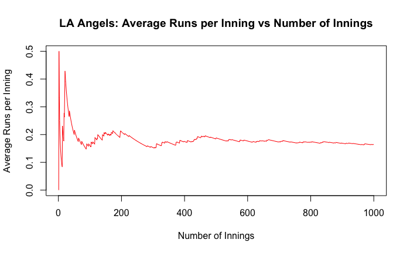

```r
# Parameters
start <- 1
seed_num <- 1000
total_runs <- numeric(seed_num + 1)
total_games <- numeric(seed_num + 1)

# Simulation loop
for (seed in 1:seed_num){
  total_runs[seed + 1] <- total_runs[seed] + simu.game(start, seed)[3]
  total_games[seed + 1] <- total_games[seed] + simu.game(start, seed)[2]
}

# Calculate average for each seed
average_per_seed <- total_runs / total_games

# Create a line plot
plot(1:seed_num, average_per_seed[-1], type = "l", col = "red", xlab = "Number of Innings", ylab = "Average Runs per Inning", main = "LA Angels: Average Runs per Inning vs Number of Innings")
```

```r
# Your plot code
```